# multitask_prac_paramsBehav

K. Garner

29/08/2018

### Summary

Having identified the candidate network underpinning modulations in connectivity due to multitasking practice, we sought to identify whether parameter estimates for each subject correlate with the observed behaviour, and whether correlation differences are different between groups. We would expect the parameter estimates to correspond to practice-related reductions in multitasking costs, rather than to reductions of response time under single-task conditions (i.e. when there is no multitasking).

### What this code does:

1. load the subject individual parameter estimates (Session 1 DCM - influence of multitasking)
2. load the behaviour and extract variables of interest - join to the parameter estimate data
3. Plot correlations between parameter estimates and behaviour and perform correlation tests between estimated parameters and observed data
4. Load subject parameter estimates
5. Load behavioural data and extract variables of interest, and join to parameter data
6. Plot the data and compute pearson and spearman correlations

# params vs. Sum DC Diff

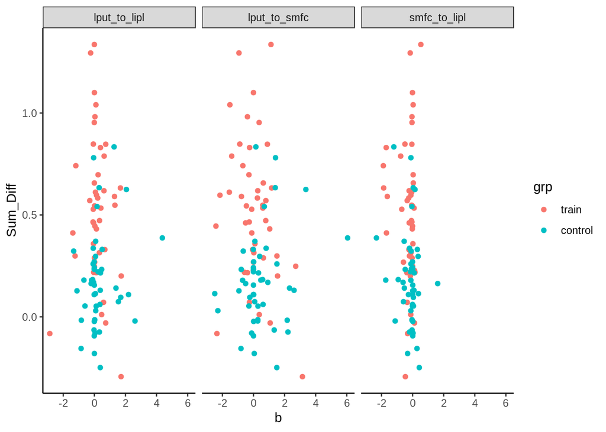

```r
draw.scatters.grp(data, "Sum_Diff")
```

```r
lapply(unique(data$con), get.cors, data = data, dv = "Sum_Diff", method="spearman")
```

```
## [[1]]
##
##  Spearman's rank correlation rho
##
## data:  x and y
## S = 134580, p-value = 0.7909
## alternative hypothesis: true rho is not equal to 0
## sample estimates:
##        rho
## 0.02770694
##
##
## [[2]]
##
##  Spearman's rank correlation rho
##
## data:  x and y
## S = 151390, p-value = 0.3688
## alternative hypothesis: true rho is not equal to 0
## sample estimates:
##         rho
## -0.09374052
##
##
## [[3]]
##
##  Spearman's rank correlation rho
##
## data:  x and y
## S = 158000, p-value = 0.1733
## alternative hypothesis: true rho is not equal to 0
## sample estimates:
##        rho
## -0.1415237
```

### Testing group differences on parameter values per se

```r
grps.mod = lme(b ~ con + grp + con*grp, random = ~1|sub,
               data   = data,
               method = "REML")
Anova(grps.mod, type="II")
```

```
## Analysis of Deviance Table (Type II tests)
##
## Response: b
##           Chisq Df Pr(>Chisq)
## con     17.6988  2  0.0001435 ***
## grp      3.8473  1  0.0498264 *
## con:grp  1.5526  2  0.4601037
## ---
## Signif. codes:  0 '***' 0.001 '**' 0.01 '*' 0.05 '.' 0.1 ' ' 1
```

There is a main effect of parameter and a main effect of group (using type II SS as no statistical interaction).

Plotting b parameters by parameter and by group

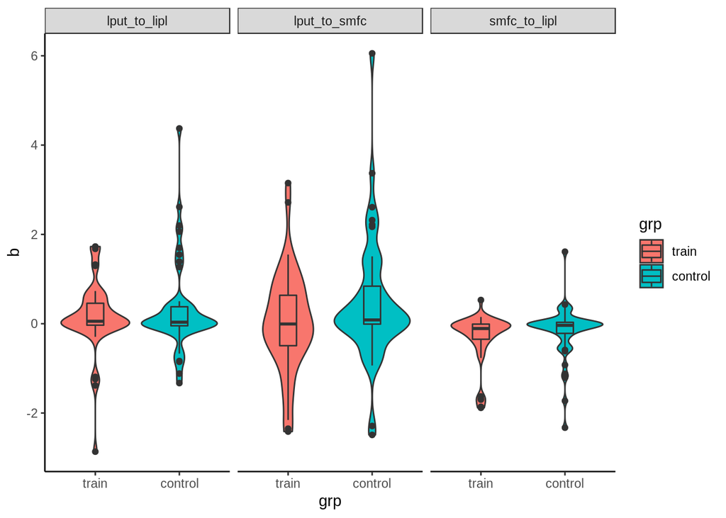

```r
plot.grp.violins(data)
```